# projetSerieTemporelleCopie

mohamedhediyedes

2026-04-18

# Phase 1. Analyse exploratoire

# 1. Importation des données

```r
data <- read_excel("C:/Users/MSI/Downloads/USA.xlsx")
head(data)
```

```
## # A tibble: 6 × 2
##   date                Index
##   <dttm>              <dbl>
## 1 1992-01-01 00:00:00  6301
## 2 1992-02-01 00:00:00  5559
## 3 1992-03-01 00:00:00  5351
## 4 1992-04-01 00:00:00  5247
## 5 1992-05-01 00:00:00  5047
## 6 1992-06-01 00:00:00  5850
```

**Interpretation :** Les donnees sont correctement importees et correspondent a une serie temporelle liee a la production pharmaceutique aux Etats-Unis.

## 2. Construction de la serie temporelle

```r
ts_data <- ts(data$Index, start = c(1992,1), frequency = 12)
ts_data
```

```
##        Jan   Feb   Mar   Apr   May   Jun   Jul   Aug   Sep   Oct   Nov   Dec
## 1992  6301  5559  5351  5247  5047  5850  5351  5479  6309  5412  5620  6009
## 1993  5947  5716  6080  5508  5174  6225  5457  5600  6746  5902  6008  6367
## 1994  6090  5732  6417  5951  5773  6587  5744  6426  7180  6275  6655  6700
## 1995  6511  6265  6818  6285  5962  6762  6169  6879  7449  6941  6990  7588
## 1996  7042  6393  7386  6643  6618  6999  6728  7046  7972  7894  7532  7987
## 1997  8158  7176  7577  7295  7336  7995  7386  7416  8456  8068  7684  8386
## 1998  8243  7518  8924  7992  7945  8929  8111  8555  9943  8577  9020  9704
## 1999  8716  8187  9707  9271  8806  9932  8589  9114 10139  9474  9138  9278
## 2000  9147  8832  9271  9450  9568  9921  9173  9999 10578 10219 10492 11378
## 2001 10550 10035 10880 10473 11141 10003  9860 11036 11184 11230 11561 12068
## 2002 11316 10402 11526 10909 11573 13118 10507 11034 13926 13238 12381 13048
## 2003 12456 11607 13464 12059 11805 12164 13545 12292 13616 13814 12874 12231
## 2004 12137 11608 13110 12099 12734 13384 12804 13744 13250 14480 14823 13437
## 2005 13546 12409 14559 13709 14145 13330 13115 15164 14049 15382 15790 14028
## 2006 14140 12927 15705 14549 15948 14616 15036 16450 14710 16254 15865 14734
## 2007 15630 14626 16325 15709 16182 15298 15559 15963 14708 17090 15312 15997
## 2008 15365 15282 15794 16274 15509 15694 16226 15645 16238 17814 16289 17136
## 2009 15629 15733 16951 16310 16031 16473 16206 15816 15734 16666 15251 16269
## 2010 14483 14062 16018 14949 14985 15817 14953 15961 16263 15781 16127 16175
## 2011 14675 14564 17588 16093 16667 17465 15622 17227 16769 16447 17488 16958
## 2012 15418 16423 16849 15932 16645 15988 15656 15848 14615 16162 14644 14856
## 2013 14701 13775 15440 15298 15780 15133 15654 15617 16046 16656 15479 16410
## 2014 15738 14925 16852 17636 16895 17244 16379 16594 17123 16878 15614 17443
## 2015 16022 15838 18182 17538 17770 19108 19208 19326 20560 19595 18921 20609
## 2016 19212 18851 21927 20333 20955 21481 19552 20957 21039 20323 20682 21485
## 2017 20421 19959 22717 21337 23174 22606 21378 23464 23190 23321 23189 23828
```

**Interpretation :** La serie est mensuelle (12 observations par an) et debute en janvier 1992.

## 3. Visualisation de la serie

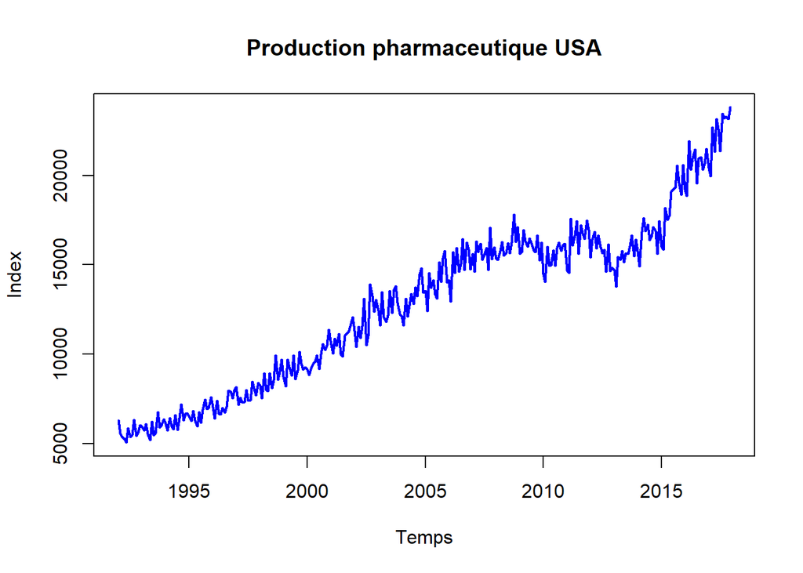

```r
plot(ts_data,
     main = "Production pharmaceutique USA",
     ylab = "Index",
     xlab = "Temps",
     col = "blue",
     lwd = 2)
```

**Interpretation :** Le graphique met en evidence une tendance globale croissante et une composante saisonniere visible. L’amplitude semble augmenter avec le niveau de la serie, ce qui peut suggerer un comportement multiplicatif.

## 4. Statistiques descriptives

```r
summary(ts_data)
```

```
##    Min. 1st Qu.  Median    Mean 3rd Qu.    Max.
##    5047    8530   13662   12847   16058   23828
```

```r
mean(ts_data)
```

```
## [1] 12847.43
```

```r
sd(ts_data)
```

```
## [1] 4685.796
```

```r
var(ts_data)
```

```
## [1] 21956684
```

**Interpretation :** Ces statistiques fournissent un premier resume de la position, de la dispersion et de la variabilite de la serie.

## 5. Décomposition de la série

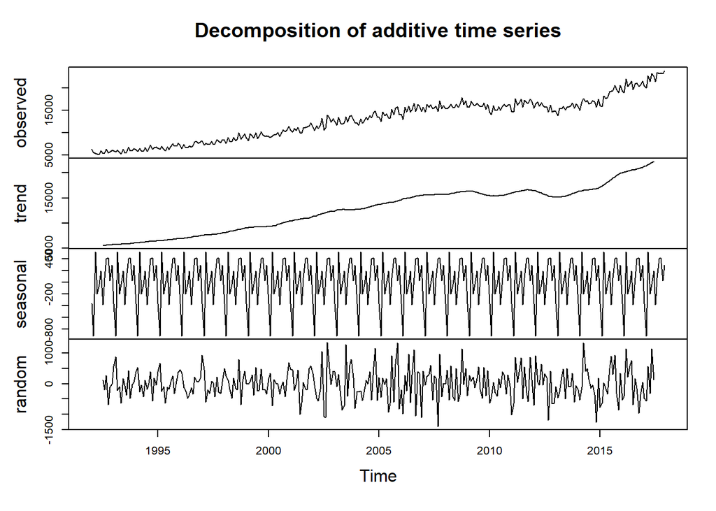

```r
t <- seq_along(ts_data)
decadd <- decompose(ts_data, type = "additive")
decmult <- decompose(ts_data, type = "multiplicative")
plot(decadd)
```

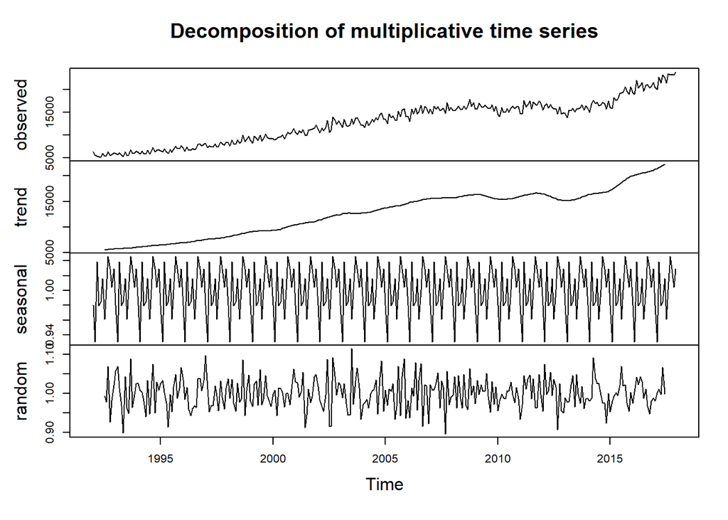

```r
plot(decmult)
```

**Interprétation :**  
La serie est decomposee en tendance, saisonnalite et residu. Le schema multiplicatif parait plus coherent lorsque la variabilite augmente avec le niveau de la serie.

## 6. ACF des residus de decomposition

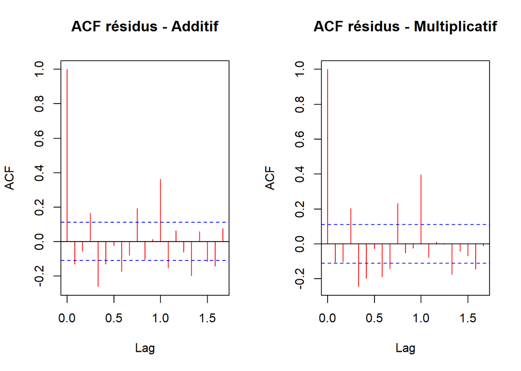

```r
par(mfrow = c(1,2))

acf(decadd$random,
    lag.max = 20,
    type = "correlation",
    plot = TRUE,
    col = "red",
    main = "ACF résidus - Additif",
    na.action=na.pass)
acf(decmult$random,
    lag.max = 20,
    type = "correlation",
    plot = TRUE,
    col = "red",
    main = "ACF résidus - Multiplicatif",
    na.action=na.pass)
```

## 7. ACF et PACF de la serie brute

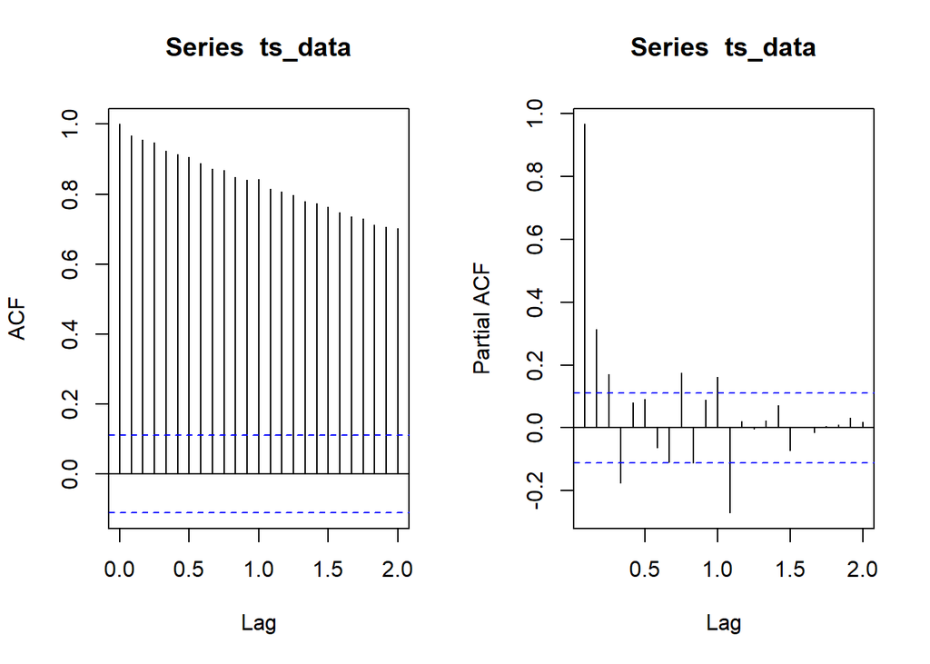

```r
par(mfrow=c(1,2))

acf(ts_data)
pacf(ts_data)
```

**Interprétation :**  
La decroissance lente de l’ACF indique une non-stationnarite (presence de tendance). La structure periodique observee soutient egalement l’existence d’une composante saisonniere.

## 8. Lag plots (dependance temporelle)

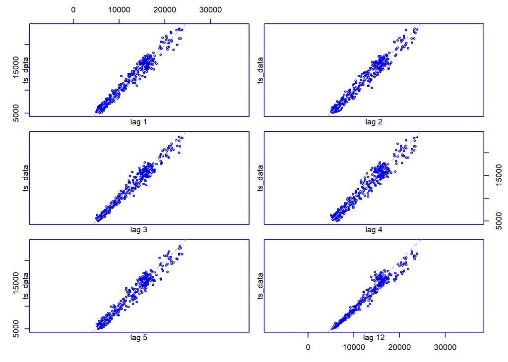

```r
lag.plot(ts_data,
         set.lags = c(1:5, 12),
         layout = c(3, 2),
         col = "blue",
         do.lines = FALSE)
```

**Interprétation :**  
Les nuages retardes montrent une dependance temporelle nette entre la serie et ses retards, en particulier au retard 12, ce qui est coherent avec une saisonnalite mensuelle.

## 9. Saisonnalite mensuelle

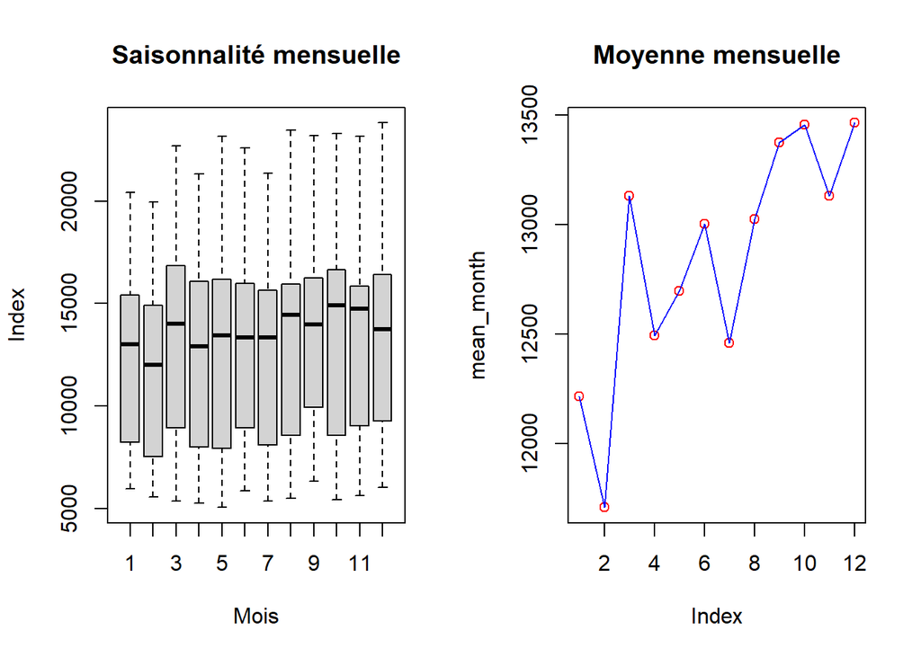

```r
par(mfrow = c(1, 2))

boxplot(ts_data ~ cycle(ts_data),
        main="Saisonnalité mensuelle",
        xlab="Mois",
        ylab="Index")

mean_month = tapply(ts_data, cycle(ts_data), mean)

plot(mean_month,
     col="red",
     main="Moyenne mensuelle")

lines(mean_month, col="blue")
```

# 10. Tests de stationnarité

```r
adf.test(ts_data)
```

```
##
##  Augmented Dickey-Fuller Test
##
## data:  ts_data
## Dickey-Fuller = -1.1258, Lag order = 6, p-value = 0.9172
## alternative hypothesis: stationary
```

**Interprétation :**  
Si la p-value est superieure a 0.05, on ne rejette pas l’hypothese nulle de non-stationnarite: la serie doit etre transformee (par exemple detrendance et/ou differenciation).

# Phase 2. Modelisation de la tendance et de la saisonnalite

## 1. Ajustement de la tendance

### 1.1. Moyenne mobile

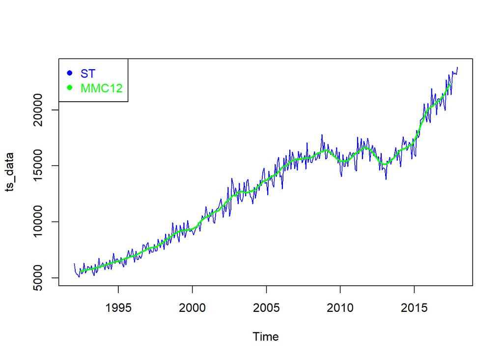

```r
MMC12 <- filter(ts_data, filter = rep(1/12, 12), method = "convolution", sides = 2)
plot(ts_data, col="blue", lwd=1)
lines(MMC12, col="green", lwd=2)
legend(x="topleft",legend=c("ST", "MMC12"), text.col=c("blue","green"),
pch=c(16,16), col=c("blue","green"))
```

**Interprétation :**  
La moyenne mobile lisse la serie et facilite la lecture de la tendance de fond.

### 1.2. Regression lineaire

```r
modelRL <- lm(ts_data ~ t)
summary(modelRL)
```

```
##
## Call:
## lm(formula = ts_data ~ t)
##
## Residuals:
##     Min      1Q  Median      3Q     Max
## -3955.5  -690.8   -13.5   704.4  3192.6
##
## Coefficients:
##              Estimate Std. Error t value Pr(>|t|)
## (Intercept) 5009.4034   141.2555   35.46   <2e-16 ***
## t             50.0832     0.7823   64.02   <2e-16 ***
## ---
## Signif. codes:  0 '***' 0.001 '**' 0.01 '*' 0.05 '.' 0.1 ' ' 1
##
## Residual standard error: 1245 on 310 degrees of freedom
## Multiple R-squared:  0.9297, Adjusted R-squared:  0.9295
## F-statistic:  4099 on 1 and 310 DF,  p-value: < 2.2e-16
```

**Interprétation :**  
Le modele lineaire capte une tendance globale simple. La significativite des coefficients se juge a partir des p-values du resume du modele.

### 1.3. Regression polynomiale de degre 2

```r
modelPoly2 <- lm(ts_data ~ t + I(t^2))
summary(modelPoly2)
```

```
##
## Call:
## lm(formula = ts_data ~ t + I(t^2))
##
## Residuals:
##     Min      1Q  Median      3Q     Max
## -3927.1  -670.6    13.8   658.7  3519.9
##
## Coefficients:
##               Estimate Std. Error t value Pr(>|t|)
## (Intercept)  4.676e+03  2.116e+02  22.101   <2e-16 ***
## t            5.646e+01  3.121e+00  18.088   <2e-16 ***
## I(t^2)      -2.037e-02  9.658e-03  -2.109   0.0357 *
## ---
## Signif. codes:  0 '***' 0.001 '**' 0.01 '*' 0.05 '.' 0.1 ' ' 1
##
## Residual standard error: 1238 on 309 degrees of freedom
## Multiple R-squared:  0.9307, Adjusted R-squared:  0.9302
## F-statistic:  2074 on 2 and 309 DF,  p-value: < 2.2e-16
```

**Interprétation :**  
Le terme quadratique permet une courbure de la tendance, donc un ajustement potentiellement plus flexible que le modele lineaire.

# 1.4 Régression polynomiale de degres 3

```r
modelPoly3 <- lm(ts_data ~ t + I(t^2) + I(t^3))
summary(modelPoly3)
```

```
##
## Call:
## lm(formula = ts_data ~ t + I(t^2) + I(t^3))
##
## Residuals:
##     Min      1Q  Median      3Q     Max
## -3753.3  -826.4    -5.8   749.0  2998.7
##
## Coefficients:
##               Estimate Std. Error t value Pr(>|t|)
## (Intercept)  4.134e+03  2.803e+02  14.747  < 2e-16 ***
## t            7.706e+01  7.744e+00   9.951  < 2e-16 ***
## I(t^2)      -1.847e-01  5.744e-02  -3.215  0.00144 **
## I(t^3)       3.499e-04  1.206e-04   2.900  0.00399 **
## ---
## Signif. codes:  0 '***' 0.001 '**' 0.01 '*' 0.05 '.' 0.1 ' ' 1
##
## Residual standard error: 1223 on 308 degrees of freedom
## Multiple R-squared:  0.9325, Adjusted R-squared:  0.9319
## F-statistic:  1419 on 3 and 308 DF,  p-value: < 2.2e-16
```

**Interprétation :**  
Le modele de degre 3 ajoute de la flexibilite supplementaire. Il faut toutefois surveiller le risque de sur-ajustement.

## 2. Comparaison visuelle des tendances

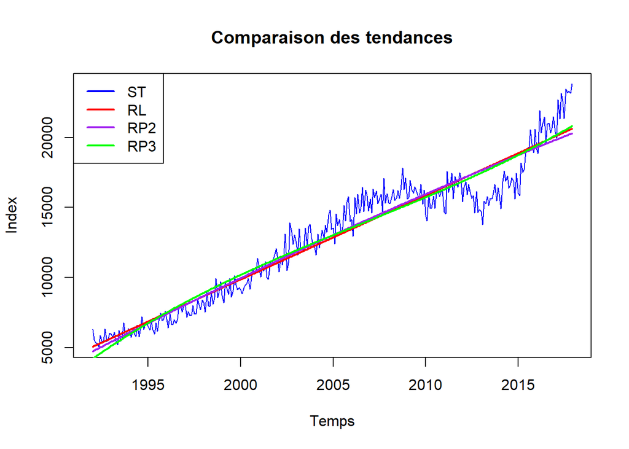

```r
par(mfrow=c(1,1))

x_time <- as.numeric(time(ts_data))
y_data <- as.numeric(ts_data)

### Série brute avec les différentes tendances
plot(x_time,
     y_data,
     type="l",
     col="blue",
     main="Comparaison des tendances",
     ylab="Index",
     xlab="Temps")

lines(x_time,
     as.numeric(fitted(modelRL)),
      col="red",
      lwd=2)

lines(x_time,
     as.numeric(fitted(modelPoly2)),
      col="purple",
      lwd=2)

lines(x_time,
     as.numeric(fitted(modelPoly3)),
      col="green",
      lwd=2)

legend("topleft",legend = c("ST", "RL", "RP2", "RP3"),col = c("blue","red","purple","green"),lwd = 2)
```

**Interprétation :**  
Dans le modele linéaire est ajusté sur la série brute et tente d’expliquer simultanément la tendance et la variabilité saisonnière et conduit mécaniquement à un coefficient de détermination relativement (𝑅2 = 0.9297).

Dans le modele polynomial de degres 2 est ajusté sur la série brute et tente d’expliquer simultanément la tendance et la variabilité saisonnière et conduit mécaniquement à un coefficient de détermination relativement (𝑅2 = 0.9307).

Dans le modele polynomail de degres 3 est ajusté sur la série brute et tente d’expliquer simultanément la tendance et la variabilité saisonnière et conduit mécaniquement à un coefficient de détermination relativement (𝑅2 = 0.9325).

on choisis le modele ayant le r_squared la plus grande alors le meilleur modele est le polynomial de degres 3

## 2.1. Comparaison des tendences par AIC et BIC

```r
# AIC
AIC(modelRL, modelPoly2, modelPoly3)
```

```
##            df      AIC
## modelRL     3 5336.359
## modelPoly2  4 5333.899
## modelPoly3  5 5327.491
```

```r
# BIC
BIC(modelRL, modelPoly2, modelPoly3)
```

```
##            df      BIC
## modelRL     3 5347.588
## modelPoly2  4 5348.871
## modelPoly3  5 5346.206
```

## 3. Estimation de la saisonnalite apres retrait de la tendance

### 3.1. Cas de la regression lineaire

```r
saisonnaliteResidusRL <- ts_data - fitted(modelRL)

saisonnaliteResidusRLstd <- as.numeric(scale(saisonnaliteResidusRL))
saisonnaliteResidusRLstd <- ts(saisonnaliteResidusRLstd,
                               start = start(ts_data),
                               frequency = frequency(ts_data))

t_time <- as.numeric(time(ts_data))

modeleSaisRL <- lm(saisonnaliteResidusRLstd ~
                     cos(2*pi*t_time/12) + cos(4*pi*t_time/12) +
                     sin(2*pi*t_time/12) + sin(4*pi*t_time/12))

summary(modeleSaisRL)
```

```
##
## Call:
## lm(formula = saisonnaliteResidusRLstd ~ cos(2 * pi * t_time/12) +
##     cos(4 * pi * t_time/12) + sin(2 * pi * t_time/12) + sin(4 *
##     pi * t_time/12))
##
## Residuals:
##      Min       1Q   Median       3Q      Max
## -2.31835 -0.62052 -0.01185  0.60258  2.46399
##
## Coefficients:
##                         Estimate Std. Error t value Pr(>|t|)
## (Intercept)             -0.04999    0.04876  -1.025  0.30608
## cos(2 * pi * t_time/12)  0.18749    0.06792   2.761  0.00612 **
## cos(4 * pi * t_time/12)  0.13828    0.06910   2.001  0.04624 *
## sin(2 * pi * t_time/12)  0.67078    0.06988   9.599  < 2e-16 ***
## sin(4 * pi * t_time/12)  0.17667    0.06845   2.581  0.01031 *
## ---
## Signif. codes:  0 '***' 0.001 '**' 0.01 '*' 0.05 '.' 0.1 ' ' 1
##
## Residual standard error: 0.8543 on 307 degrees of freedom
## Multiple R-squared:  0.2796, Adjusted R-squared:  0.2702
## F-statistic: 29.79 on 4 and 307 DF,  p-value: < 2.2e-16
```

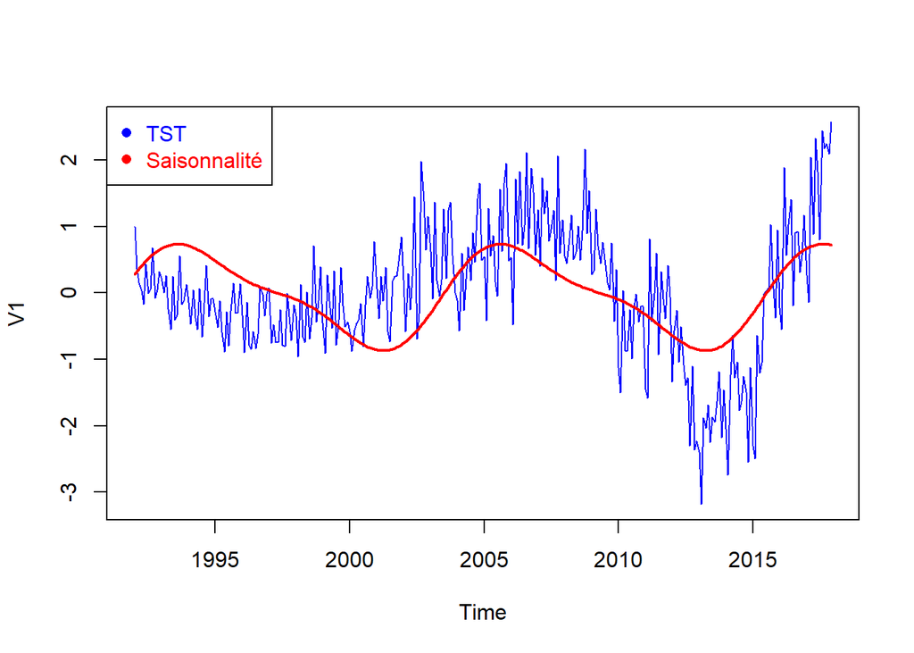

```r
plot(saisonnaliteResidusRLstd, col="blue", ylab="V1")
points(time(ts_data),fitted(modeleSaisRL),type="l",col="red",
lwd = 2)
legend(x="topleft",legend=c("TST", "Saisonnalité"),
text.col=c("blue","red"),
pch=c(16,16), col=c("blue","red"))
```

### 3.2. Cas de la regression polynomiale degre 2

```r
saisonnaliteResidusPoly2 <- ts_data - fitted(modelPoly2)

saisonnaliteResidusPoly2std <- as.numeric(scale(saisonnaliteResidusPoly2))
saisonnaliteResidusPoly2std <- ts(saisonnaliteResidusPoly2std,
                                  start = start(ts_data),
                                  frequency = frequency(ts_data))

modeleSaispoly2 <- lm(saisonnaliteResidusPoly2std ~
                        cos(2*pi*t_time/12) + cos(4*pi*t_time/12) +
                        sin(2*pi*t_time/12) + sin(4*pi*t_time/12))

summary(modeleSaispoly2)
```

```
##
## Call:
## lm(formula = saisonnaliteResidusPoly2std ~ cos(2 * pi * t_time/12) +
##     cos(4 * pi * t_time/12) + sin(2 * pi * t_time/12) + sin(4 *
##     pi * t_time/12))
##
## Residuals:
##      Min       1Q   Median       3Q      Max
## -2.26049 -0.56504 -0.02868  0.58549  2.36711
##
## Coefficients:
##                         Estimate Std. Error t value Pr(>|t|)
## (Intercept)             -0.05670    0.04710  -1.204 0.229611
## cos(2 * pi * t_time/12)  0.24165    0.06561   3.683 0.000272 ***
## cos(4 * pi * t_time/12)  0.15558    0.06675   2.331 0.020418 *
## sin(2 * pi * t_time/12)  0.70456    0.06751  10.437  < 2e-16 ***
## sin(4 * pi * t_time/12)  0.20353    0.06613   3.078 0.002273 **
## ---
## Signif. codes:  0 '***' 0.001 '**' 0.01 '*' 0.05 '.' 0.1 ' ' 1
##
## Residual standard error: 0.8253 on 307 degrees of freedom
## Multiple R-squared:  0.3277, Adjusted R-squared:  0.3189
## F-statistic: 37.41 on 4 and 307 DF,  p-value: < 2.2e-16
```

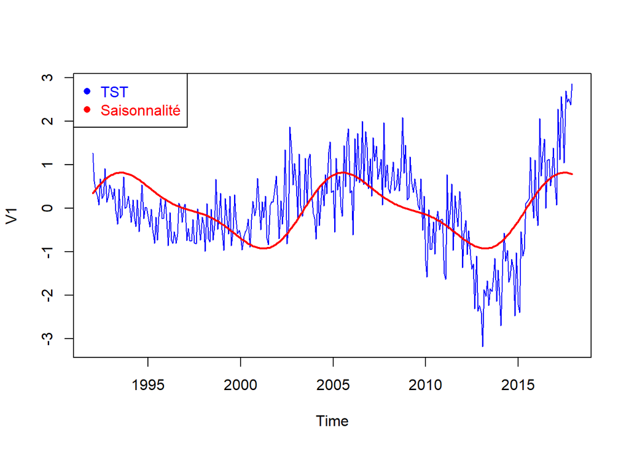

```r
plot(saisonnaliteResidusPoly2std, col="blue", ylab="V1")
points(time(ts_data), fitted(modeleSaispoly2), type="l", col="red", lwd=2)
legend(x="topleft", legend=c("TST", "Saisonnalité"),
       text.col=c("blue","red"),
       pch=c(16,16), col=c("blue","red"))
```

**Interprétation :**  
La saisonnalite est estimee de la meme facon apres retrait de la tendance quadratique, ce qui permet de comparer les residus entre modeles.

### 3.3. Cas de la regression polynomiale degre 3

```r
saisonnaliteResidusPoly3 <- ts_data - fitted(modelPoly3)

saisonnaliteResidusPoly3std <- as.numeric(scale(saisonnaliteResidusPoly3))
saisonnaliteResidusPoly3std <- ts(saisonnaliteResidusPoly3std,
                                  start = start(ts_data),
                                  frequency = frequency(ts_data))


modeleSaispoly3 <- lm(saisonnaliteResidusPoly3std ~
                        cos(2*pi*t_time/12) + cos(4*pi*t_time/12) +
                        sin(2*pi*t_time/12) + sin(4*pi*t_time/12))

summary(modeleSaispoly3)
```

```
##
## Call:
## lm(formula = saisonnaliteResidusPoly3std ~ cos(2 * pi * t_time/12) +
##     cos(4 * pi * t_time/12) + sin(2 * pi * t_time/12) + sin(4 *
##     pi * t_time/12))
##
## Residuals:
##      Min       1Q   Median       3Q      Max
## -2.16454 -0.58824 -0.05845  0.60044  2.31452
##
## Coefficients:
##                         Estimate Std. Error t value Pr(>|t|)
## (Intercept)             -0.05747    0.04639  -1.239 0.216374
## cos(2 * pi * t_time/12)  0.23386    0.06462   3.619 0.000346 ***
## cos(4 * pi * t_time/12)  0.15352    0.06574   2.335 0.020180 *
## sin(2 * pi * t_time/12)  0.73428    0.06649  11.044  < 2e-16 ***
## sin(4 * pi * t_time/12)  0.20894    0.06513   3.208 0.001477 **
## ---
## Signif. codes:  0 '***' 0.001 '**' 0.01 '*' 0.05 '.' 0.1 ' ' 1
##
## Residual standard error: 0.8128 on 307 degrees of freedom
## Multiple R-squared:  0.3478, Adjusted R-squared:  0.3393
## F-statistic: 40.93 on 4 and 307 DF,  p-value: < 2.2e-16
```

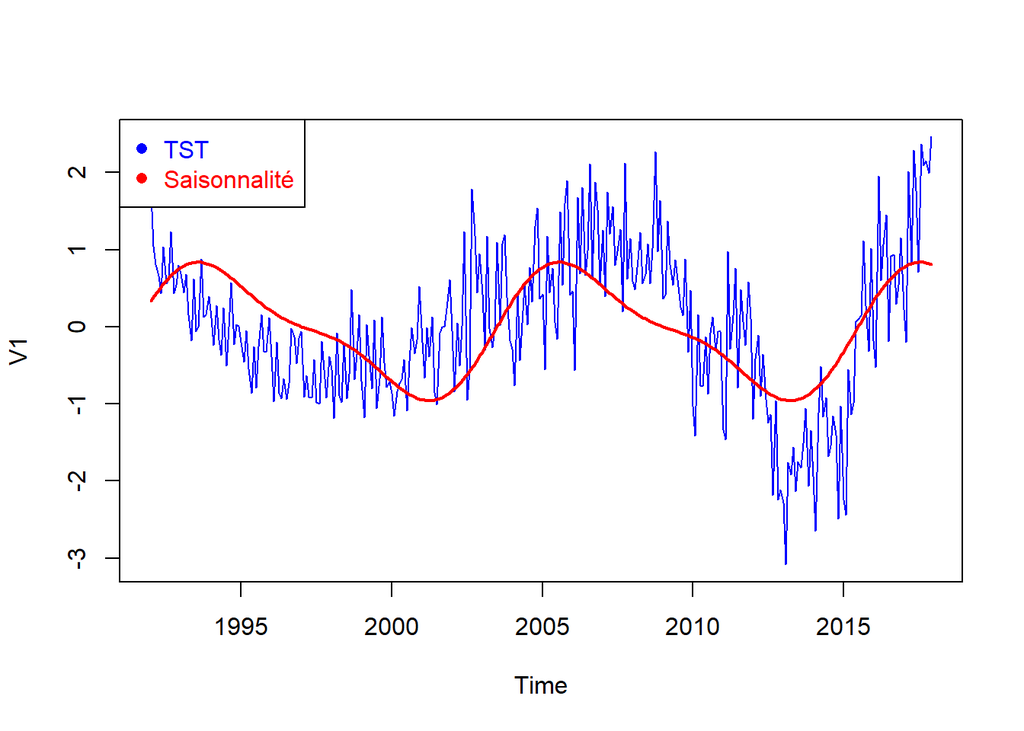

```r
plot(saisonnaliteResidusPoly3std, col="blue", ylab="V1")
points(time(ts_data), fitted(modeleSaispoly3), type="l", col="red", lwd=2)
legend(x="topleft", legend=c("TST", "Saisonnalité"),
       text.col=c("blue","red"),
       pch=c(16,16), col=c("blue","red"))
```

**Interprétation :**  
Cette etape fournit la composante saisonniere associee au modele de tendance cubique.

### 3.4. Comparaison des 3 modeles

```r
AIC(modeleSaisRL, modeleSaispoly2, modeleSaispoly3)
```

```
##                 df      AIC
## modeleSaisRL     6 794.0913
## modeleSaispoly2  6 772.5471
## modeleSaispoly3  6 763.0592
```

```r
BIC(modeleSaisRL, modeleSaispoly2, modeleSaispoly3)
```

```
##                 df      BIC
## modeleSaisRL     6 816.5493
## modeleSaispoly2  6 795.0052
## modeleSaispoly3  6 785.5172
```

**Interprétation :**  
le AIC et BIC de modeleSaispoly3 < modeleSaispoly2 <modeleSaisRL donc le modeleSaispoly3 est le model qu’il faut utiliser

### 3.5. Corrélation tendance + saisonnalité

```r
cor(ts_data, fitted(modeleSaispoly3) + fitted(modelPoly3))
```

```
## [1] 0.9656936
```

**Interprétation :**  
correclation tres importante

## 4. Analyse des residus apres retrait de la saisonnalite

### 4.1. Residus du modele lineaire

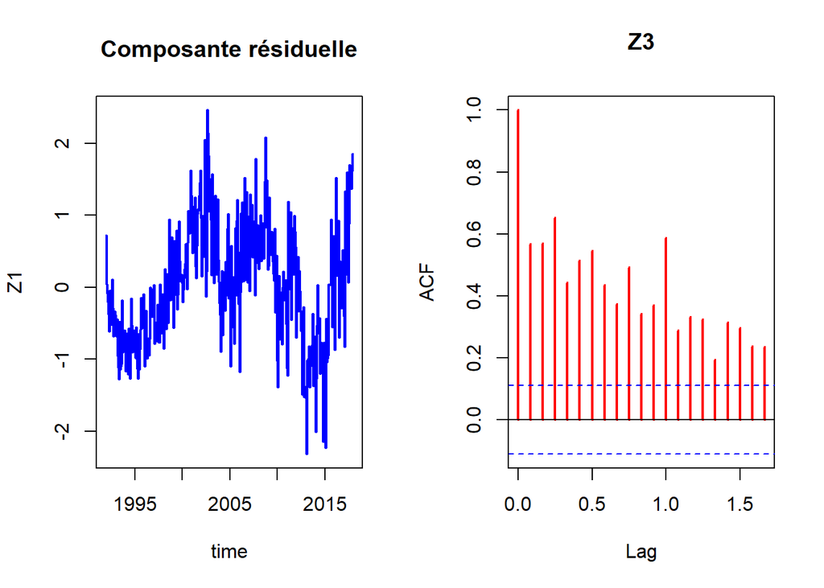

```r
Z3 = saisonnaliteResidusRLstd - fitted(modeleSaisRL)
par(mfrow = c(1,2))
plot.ts(Z3, xlab="time",ylab=" Z1 ", lwd = 2,
main="Composante résiduelle", col="blue")
acf(Z3, lag.max = 20, type = c("correlation"),
plot = TRUE, col="red", main = "Z3", lwd = 2,
na.action = na.pass)
```

**Interprétation :**  
Si des pics significatifs apparaissent dans l’ACF, les residus conservent une structure temporelle.

### 4.2. Residus du modele polynomial degre 2

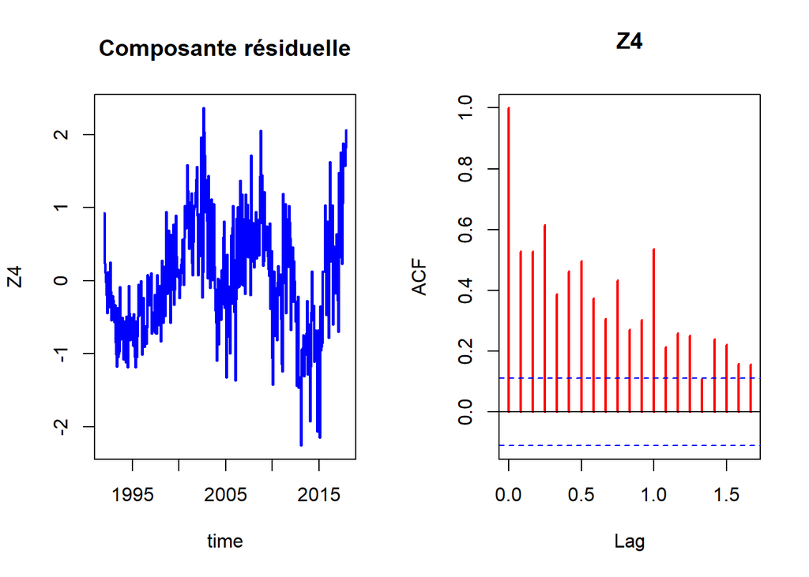

```r
Z4 = saisonnaliteResidusPoly2std - fitted(modeleSaispoly2)
par(mfrow = c(1,2))
plot.ts(Z4, xlab="time", ylab=" Z4 ", lwd = 2,
main="Composante résiduelle", col="blue")
acf(Z4, lag.max = 20, type = "correlation",
plot = TRUE, col="red", main = "Z4", lwd = 2,
na.action = na.pass)
```

**Interprétation :**  
Le correlogramme permet de verifier si le modele a bien capture la dependance temporelle principale.

### 4.3. Residus du modele polynomial degre 3

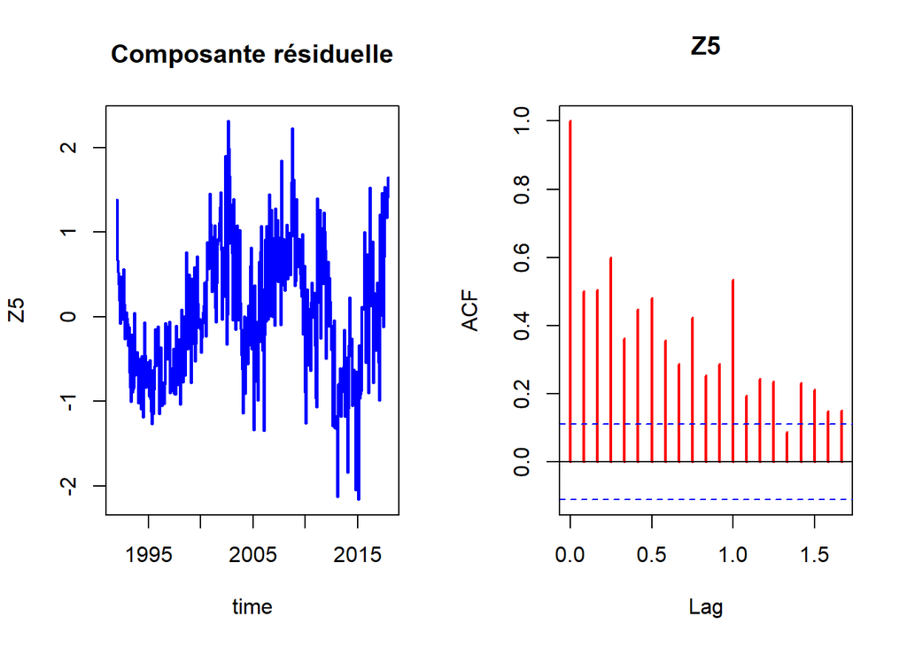

```r
Z5 = saisonnaliteResidusPoly3std - fitted(modeleSaispoly3)
par(mfrow = c(1,2))
plot.ts(Z5, xlab="time", ylab=" Z5 ", lwd = 2,
        main="Composante résiduelle", col="blue")
acf(Z5, lag.max = 20, type = "correlation",
    plot = TRUE, col="red", main = "Z5", lwd = 2,
    na.action = na.pass)
```

**Interprétation :**  
Z5 est la composante residuelle retenue pour la suite de la modelisation ARIMA.

## 5. Test de stationnarite des residus (Z5)

```r
test = adf.test(Z5)
test
```

```
##
##  Augmented Dickey-Fuller Test
##
## data:  Z5
## Dickey-Fuller = -2.5172, Lag order = 6, p-value = 0.3584
## alternative hypothesis: stationary
```

**Interprétation :**  
la p-valeur obtenue avec le test de Dickey-Fuller est supérieure à 0,05, ce qui conduit à accepter l’hypothèse nulle de non-stationnarité. On procède ensuite à une différentiation des résidus et on effectue un nouveau test de stationnarité

## 6. Differenciation des residus

```r
Z_diff = diff(Z5, differences = 1)
adf.test(Z_diff)
```

```
##
##  Augmented Dickey-Fuller Test
##
## data:  Z_diff
## Dickey-Fuller = -7.473, Lag order = 6, p-value = 0.01
## alternative hypothesis: stationary
```

**Interprétation :**  
La p-valeur est inférieure à 0.05, on rejette l’hypothèse nulle et on accepte l’hypothèse de stationnarité. Ce qui implique que la série résiduelle différenciée est stationnaire

**Finalement, on teste si la série résiduelle différenciée correspond à un bruit blanc. Pour ce faire, on peut procéder de deux manières :**

1. On trace la fonction d’autocorrélation (ACF) et on vérifie l’absence d’autocorrélation significative.
2. On applique le test de Ljung-Box en utilisant la commande Box.test()

## 7. Verification du bruit blanc sur la serie differenciee

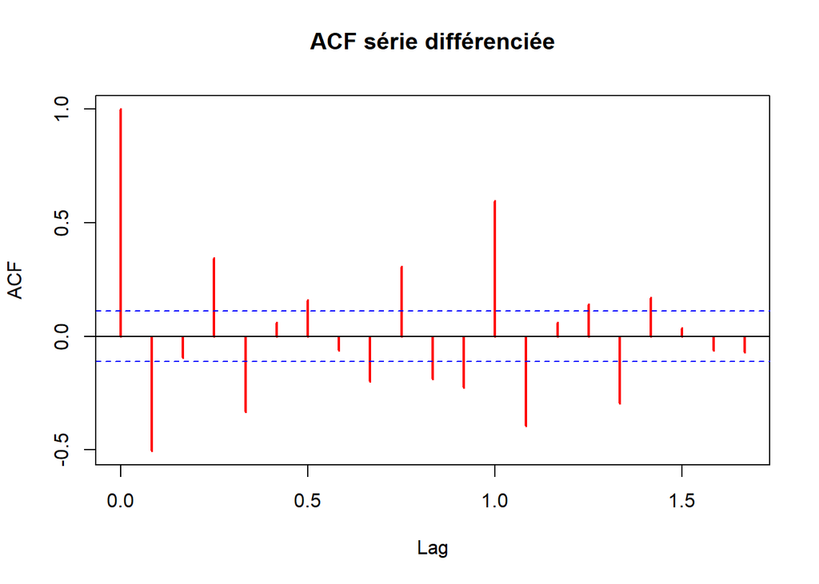

```r
acf(Z_diff, lag.max=20, col='red', main="ACF série différenciée", lwd=2)
```

```r
testB = Box.test(Z_diff, lag=20, type = "Ljung-Box")
testB
```

```
##
##  Box-Ljung test
##
## data:  Z_diff
## X-squared = 455.14, df = 20, p-value < 2.2e-16
```

**Interprétation :**  
L’ACF montre une autocorrélation, et le test de Ljung-Box, avec une p-valeur inférieure à 0.05, indique que la série n’est pas un bruit blanc. La série résiduelle présente encore une structure, ce qui indique que toute l’information n’a pas été capturée.Il convient donc de modéliser la série stationnaire obtenue à l’aide d’un modèle ARMA

# Phase 3. Modelisation ARIMA et prevision

## 1. Identification automatique du modele

```r
ARIMA=auto.arima(Z5, d=1, trace=TRUE)
```

```
##
##  Fitting models using approximations to speed things up...
##
##  ARIMA(2,1,2)(1,0,1)[12] with drift         : Inf
##  ARIMA(0,1,0)            with drift         : 746.0746
##  ARIMA(1,1,0)(1,0,0)[12] with drift         : 520.3905
##  ARIMA(0,1,1)(0,0,1)[12] with drift         : 524.4666
##  ARIMA(0,1,0)                               : 744.0489
##  ARIMA(1,1,0)            with drift         : 656.1217
##  ARIMA(1,1,0)(2,0,0)[12] with drift         : 530.9133
##  ARIMA(1,1,0)(1,0,1)[12] with drift         : 520.6003
##  ARIMA(1,1,0)(0,0,1)[12] with drift         : 553.712
##  ARIMA(1,1,0)(2,0,1)[12] with drift         : Inf
##  ARIMA(0,1,0)(1,0,0)[12] with drift         : 603.3813
##  ARIMA(2,1,0)(1,0,0)[12] with drift         : 458.9497
##  ARIMA(2,1,0)            with drift         : 578.8096
##  ARIMA(2,1,0)(2,0,0)[12] with drift         : 455.8318
##  ARIMA(2,1,0)(2,0,1)[12] with drift         : Inf
##  ARIMA(2,1,0)(1,0,1)[12] with drift         : Inf
##  ARIMA(3,1,0)(2,0,0)[12] with drift         : 458.0359
##  ARIMA(2,1,1)(2,0,0)[12] with drift         : 457.1093
##  ARIMA(1,1,1)(2,0,0)[12] with drift         : 486.6638
##  ARIMA(3,1,1)(2,0,0)[12] with drift         : 460.0452
##  ARIMA(2,1,0)(2,0,0)[12]                    : 454.1305
##  ARIMA(2,1,0)(1,0,0)[12]                    : 457.1418
##  ARIMA(2,1,0)(2,0,1)[12]                    : Inf
##  ARIMA(2,1,0)(1,0,1)[12]                    : Inf
##  ARIMA(1,1,0)(2,0,0)[12]                    : 528.9742
##  ARIMA(3,1,0)(2,0,0)[12]                    : 456.2524
##  ARIMA(2,1,1)(2,0,0)[12]                    : 455.3667
##  ARIMA(1,1,1)(2,0,0)[12]                    : 485.006
##  ARIMA(3,1,1)(2,0,0)[12]                    : 458.2592
##
##  Now re-fitting the best model(s) without approximations...
##
##  ARIMA(2,1,0)(2,0,0)[12]                    : 442.3476
##
##  Best model: ARIMA(2,1,0)(2,0,0)[12]
```

**Interprétation :**  
selon le test de ARMA on a trouver que le meilleur model est : ARIMA(2,1,0)(2,0,0)[12]

## 2. Estimation du modele retenu et diagnostics

```r
ARMA = arima(Z5,order = c(2, 1, 0),seasonal = list(order = c(2, 0, 0), period = 12))
summary(ARMA)
```

```
##
## Call:
## arima(x = Z5, order = c(2, 1, 0), seasonal = list(order = c(2, 0, 0), period = 12))
##
## Coefficients:
##           ar1      ar2    sar1    sar2
##       -0.7607  -0.4920  0.4510  0.2282
## s.e.   0.0515   0.0515  0.0567  0.0591
##
## sigma^2 estimated as 0.2296:  log likelihood = -216.08,  aic = 442.15
##
## Training set error measures:
##                       ME      RMSE       MAE      MPE     MAPE      MASE
## Training set 0.009103816 0.4784048 0.3665834 246.5361 427.7613 0.6418115
##                    ACF1
## Training set 0.02721081
```

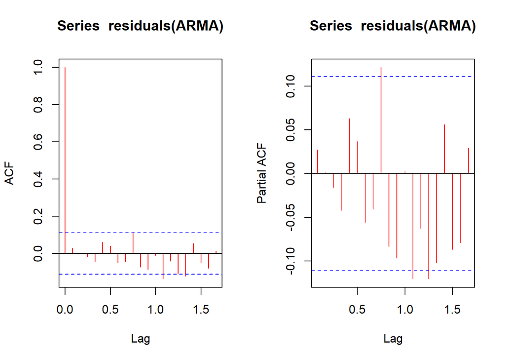

```r
par(mfrow=c(1, 2))

### Diagnostic du modele ARIMA
acf(residuals(ARMA), lag.max = 20, type = "correlation", plot = TRUE, col="red")
pacf(residuals(ARMA), lag.max = 20, plot = TRUE, col="red")
```

```r
# Tracé de la serie et de l'ajustement
plot(Z5, xlab="Time", ylab="Z5",main="Série résiduelle",col="blue", lwd=1, type="l")
lines(fitted(ARMA), col="red", lwd=1)
# Ajouter la légende
legend("topleft",
legend = c("Z5 originale", "Z5 estimée"),
col = c("blue", "red"),
lwd = 2,
bg = "gray90")

testBox = Box.test(residuals(ARMA), lag = 24, type = "Ljung-Box", fitdf = 4)
testBox
```

[output not shown]

```
##
##  Box-Ljung test
##
## data:  residuals(ARMA)
## X-squared = 41.166, df = 20, p-value = 0.003547
```

```r
testJB = jarque.bera.test(residuals(ARMA))
testJB
```

```
##
##  Jarque Bera Test
##
## data:  residuals(ARMA)
## X-squared = 8.5946, df = 2, p-value = 0.0136
```

```
##
##  Ljung-Box test
##
## data:  Residuals from ARIMA(2,1,0)(2,0,0)[12]
## Q* = 41.166, df = 20, p-value = 0.003547
##
## Model df: 4.   Total lags used: 24
```

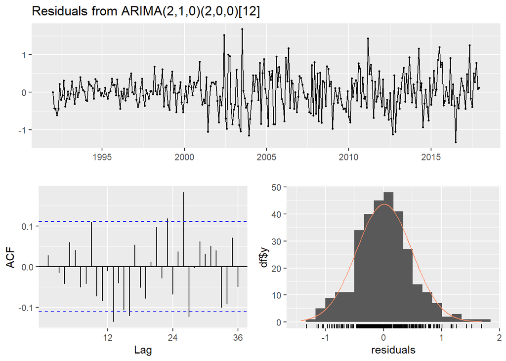

```r
checkresiduals(ARMA)
```

**Interprétation :**  
Après l’estimation du modèle ARIMA, plusieurs outils de diagnostic ont été utilisés afin d’évaluer la qualité de l’ajustement du modèle.

Tout d’abord, l’analyse des fonctions d’autocorrélation (ACF) et d’autocorrélation partielle (PACF) des résidus montre la présence de certaines autocorrélations significatives. Cela signifie que les résidus ne sont pas totalement indépendants et qu’il subsiste encore une structure temporelle non capturée par le modèle.

Ensuite, le test de Ljung-Box appliqué aux résidus fournit une p-valeur inférieure au seuil de signification de 5 %. On rejette donc l’hypothèse nulle d’absence d’autocorrélation, ce qui indique que les résidus ne correspondent pas à un bruit blanc.

Par ailleurs, le test de Jarque-Bera permet d’évaluer la normalité des résidus. La p-valeur obtenue étant également inférieure à 0,05, l’hypothèse de normalité des résidus est rejetée.

Ainsi, l’ensemble des diagnostics (ACF, PACF, test de Ljung-Box et test de Jarque-Bera) montre que les résidus du modèle ARIMA estimé ne se comportent pas comme un bruit blanc. Cela signifie que le modèle ne capture pas entièrement la dynamique de la série temporelle et qu’une amélioration du modèle pourrait être envisagée.

## 3. Previsions a 12 periodes

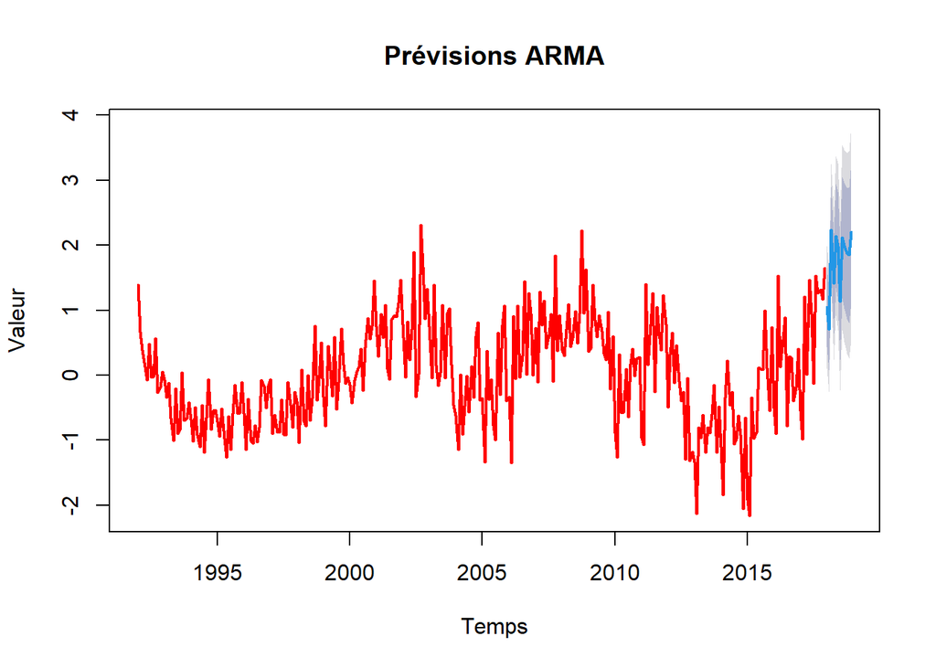

```r
prev = forecast(ARMA, h = 12)
plot(prev, type = "l", col = "red", lwd = 2, main = "Prévisions ARMA", xlab = "Temps", ylab = "Valeur")
```

**Interprétation :**  
Le graphique presente les previsions a court terme ainsi que les intervalles d’incertitude associes.